# Week 8

25 04 2021

## Week 8

## Plan

- Affiliation Networks
  - Visualization
  - Projections
  - Data Model
- Cutpoints
- Other Network Packages
  - statnet
  - network
  - intergraph
  - visNetwork
  - networkD3

## Theory

A tribe is a group of people connected to one another, connected to a leader, and connected to an idea. For millions of years, human beings have been part of one tribe or another. A group needs only two things to be a tribe: a shared interest and a way to communicate. (Seth Godin – Tribes: We Need You to Lead Us)

## Affiliation Networks

- Person 1 - Idea 1
- Person 2 - Idea 1
- Person 3 - Idea 2

A network but the members have two class not one.

## Board memberships

- Company A - Director X
- Company B - Directory Y
- Company C - Director Y

## Edge List

```r
standard.df <- read.csv("../data/02.csv")
standard.df
```

```
##    from      to
## 1   ece     ali
## 2   ece    özge
## 3   ece ibrahim
## 4   ece   ahmet
## 5   ece    suat
## 6  suat ibrahim
## 7  suat    özge
## 8  suat   sabri
## 9   ali   ahmet
## 10  ali  mehmet
```

## Data Model

## Adjacency Matrix

```r
library(igraph)
standard.g <- graph_from_data_frame(standard.df)
get.adjacency(standard.g)
```

```
## 8 x 8 sparse Matrix of class "dgCMatrix"
##         ece suat ali özge ibrahim ahmet sabri mehmet
## ece       .    1   1    1       1     1     .      .
## suat      .    .   .    1       1     .     1      .
## ali       .    .   .    .       .     1     .      1
## özge      .    .   .    .       .     .     .      .
## ibrahim   .    .   .    .       .     .     .      .
## ahmet     .    .   .    .       .     .     .      .
## sabri     .    .   .    .       .     .     .      .
## mehmet    .    .   .    .       .     .     .      .
```

## Affiliations as 2-Mode Networks (INcidence Matrix)

```r
C1 <- c(1,1,1,0,0,0)
C2 <- c(0,1,1,1,0,0)
C3 <- c(0,0,1,1,1,0)
C4 <- c(0,0,0,0,1,1)
aff.df <- data.frame(C1,C2,C3,C4)
row.names(aff.df) <- c("Selçuk Mert","Ezgi","İbrahim","Kayra","Ece","X")
aff.df
```

```
##             C1 C2 C3 C4
## Selçuk Mert  1  0  0  0
## Ezgi         1  1  0  0
## İbrahim      1  1  1  0
## Kayra        0  1  1  0
## Ece          0  0  1  1
## X            0  0  0  1
```

## Raw Visualization

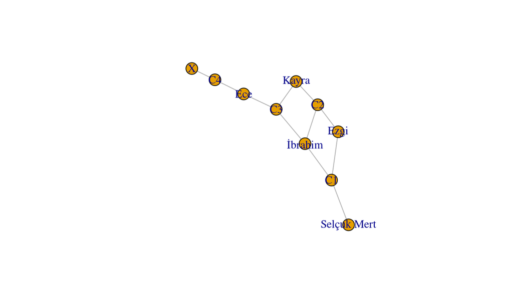

```r
#focus to the function. We doesn't use graph_from_data_frame
plot(graph_from_incidence_matrix(aff.df))
```

## Stylized Visualization

Class: Red, Student Green

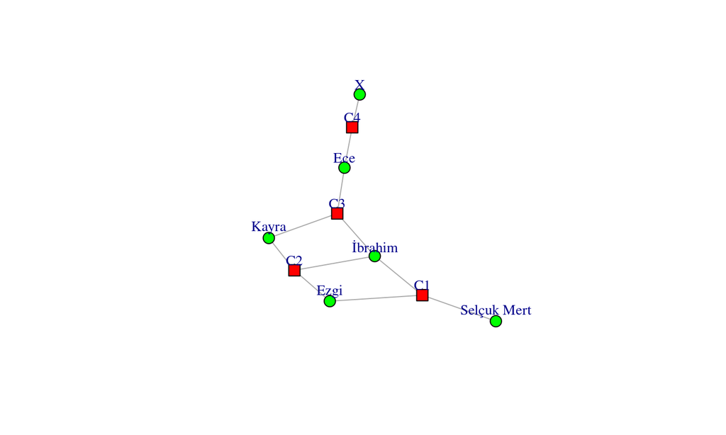

```r
library(igraph)
bn <- graph.incidence(aff.df)

shapes <- c("circle","square")
colors <- c("green","red")
plot(bn,vertex.color=colors[V(bn)$type+1],
vertex.shape=shapes[V(bn)$type+1],
vertex.size=10,vertex.label.degree=-pi/2,
vertex.label.dist=1.2,vertex.label.cex=0.9)
```

## Map Visualization

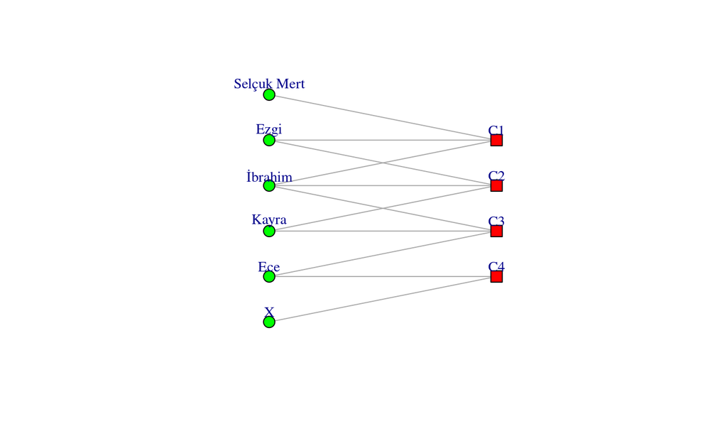

```r
library(igraph)
bn <- graph.incidence(aff.df)

# map layout

plt.x <- c(rep(2,6),rep(4,4))
plt.y <- c(7:2,6:3)
lay <- as.matrix(cbind(plt.x,plt.y))

shapes <- c("circle","square")
colors <- c("green","red")
plot(bn,vertex.color=colors[V(bn)$type+1],
vertex.shape=shapes[V(bn)$type+1],
vertex.size=10,vertex.label.degree=-pi/2,
vertex.label.dist=1.2,vertex.label.cex=0.9,
layout = lay)
```

## Projections

## We are in the same class !

Focus to two proj’s: - proj1: Student’s co-occurence - proj2: Class relations

```r
bn.pr <- bipartite.projection(bn)
bn.pr
```

```
## $proj1
## IGRAPH e3572dd UNW- 6 8 --
## + attr: name (v/c), weight (e/n)
## + edges from e3572dd (vertex names):
## [1] Selçuk Mert--Ezgi    Selçuk Mert--İbrahim Ezgi       --İbrahim
## [4] Ezgi       --Kayra   İbrahim    --Kayra   İbrahim    --Ece
## [7] Kayra      --Ece     Ece        --X
##
## $proj2
## IGRAPH 0a35fad UNW- 4 4 --
## + attr: name (v/c), weight (e/n)
## + edges from 0a35fad (vertex names):
## [1] C1--C2 C1--C3 C2--C3 C3--C4
```

## Assigning projections

```r
bn.student <- bn.pr$proj1
bn.class <- bn.pr$proj2
```

## Student’s co-occurence matrix

```r
get.adjacency(bn.student,sparse=FALSE,attr="weight")
```

```
##             Selçuk Mert Ezgi İbrahim Kayra Ece X
## Selçuk Mert           0    1       1     0   0 0
## Ezgi                  1    0       2     1   0 0
## İbrahim               1    2       0     2   1 0
## Kayra                 0    1       2     0   1 0
## Ece                   0    0       1     1   0 1
## X                     0    0       0     0   1 0
```

## Class Relations Matrix

```r
get.adjacency(bn.class,sparse=FALSE,attr="weight")
```

```
##    C1 C2 C3 C4
## C1  0  2  1  0
## C2  2  0  2  0
## C3  1  2  0  1
## C4  0  0  1  0
```

## Seperation

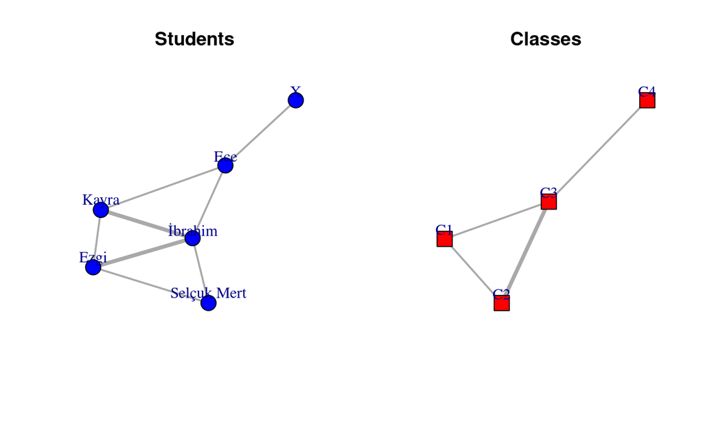

```r
shapes <- c("circle","square")
colors <- c("blue","red")
op <- par(mfrow=c(1,2))
plot(bn.student,vertex.color="blue",
vertex.shape="circle",main="Students",
edge.width=E(bn.student)$weight*2,
vertex.size=15,vertex.label.degree=-pi/2,
vertex.label.dist=1.2,vertex.label.cex=1)
plot(bn.class,vertex.color="red",
vertex.shape="square",main="Classes",
edge.width=E(bn.student)$weight*2,
vertex.size=15,vertex.label.degree=-pi/2,
vertex.label.dist=1.2,vertex.label.cex=1)
```

```r
par(op)
```

## Conceptualization 3d or more

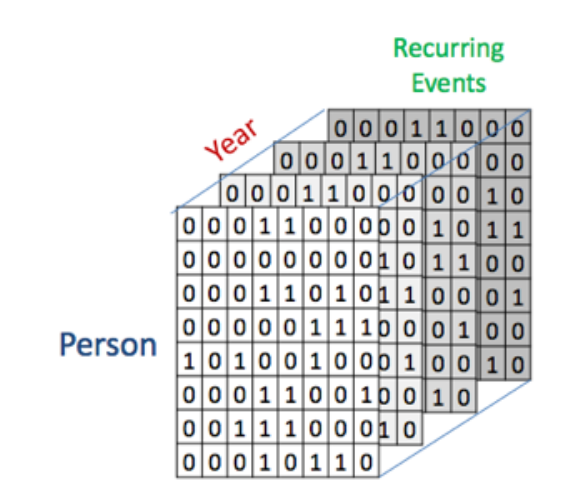

Source: [Mi-Fu](https://www.mi.fu-berlin.de/en/inf/groups/hcc/teaching/Past-Terms/Winter-Term-2015_16/CNA_Resources/05_CNA.pdf)

## Advantages and disadvantages

**Advantages:**

- They highlight the connectivity in the network, as well as the indirect chains of connection
- Data is not lost and we always know which individuals attended which events/ideas/clasess

**Disadvantage:**

- They can be unwieldy when used to depict larger affiliation networks

## CutPoints and Bridges

## Cutpoint

- A node that, if dropped, would increase the number of components in the network.
- If they were dropped, that would result in two subsets of actors that would not be able to communicate with each other

## Cutpoint Example

Who is cutpoint(s)?

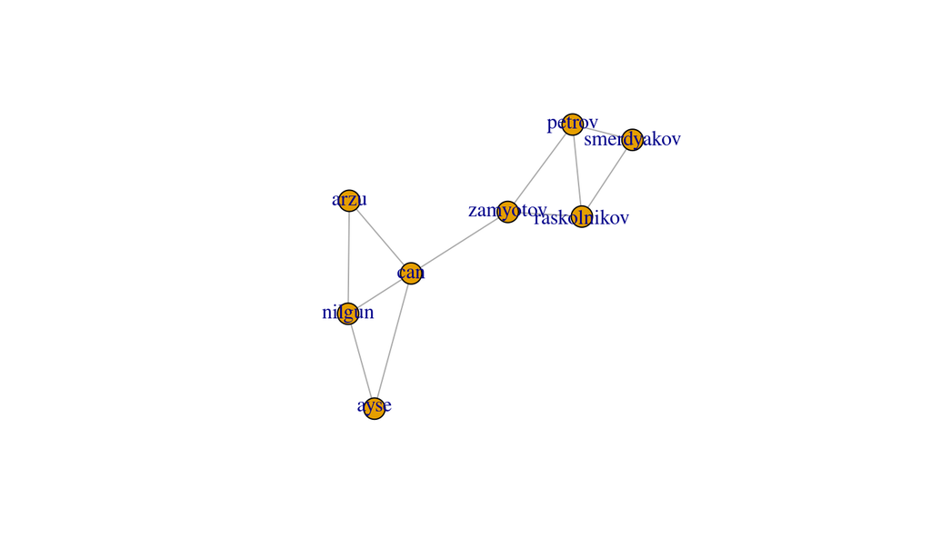

```r
library(igraph)
g_mod_a <- graph_from_data_frame(read.csv("../data/modular-a.csv"),directed = F)
plot(g_mod_a)
```

## Conversion between Network Packages

Igraph does not has cutpoint function therefore we are converting it by `intergraph` package.

```r
library(statnet) #for cutpoints function # it employs network package.
```

```r
library(igraph)
library(intergraph)
g_mod_a_network = asNetwork(g_mod_a) # convert to network type compatible with statnet
```

## Finding Cutpoints

```r
cp <- cutpoints(g_mod_a_network,mode="graph",return.indicator = TRUE)
cp
```

```
##     1     2     3     4     5     6     7     8
## FALSE FALSE FALSE FALSE  TRUE FALSE  TRUE FALSE
```

## Accessing the vertex names by Network Package

```r
g_mod_a_network %v% "vertex.names"
```

```
## [1] "raskolnikov" "smerdyakov"  "petrov"      "nilgun"      "can"
## [6] "arzu"        "zamyotov"    "ayse"
```

5 and 7 are cutpoints Can and Zamyotov.

## VizNetwork

```r
library(visNetwork)
visNetwork::visIgraph(g_mod_a)
```

[interactive chart not shown]

## Network3d

```r
# Load package
library(networkD3)

# Create fake data
src <- c("A", "A", "A", "A",
        "B", "B", "C", "C", "D")
target <- c("B", "C", "D", "J",
            "E", "F", "G", "H", "I")
networkData <- data.frame(src, target)

# Plot
simpleNetwork(networkData)
```

[interactive chart not shown]

## Sankey Networks with NetworkD3

```r
# Load energy projection data
URL <- paste0(
        "https://cdn.rawgit.com/christophergandrud/networkD3/",
        "master/JSONdata/energy.json")
Energy <- jsonlite::fromJSON(URL)
# Plot
sankeyNetwork(Links = Energy$links, Nodes = Energy$nodes, Source = "source",
             Target = "target", Value = "value", NodeID = "name",
             units = "TWh", fontSize = 12, nodeWidth = 30)
```

[interactive chart not shown]

## Dendograms with Network3D

```r
hc <- hclust(dist(USArrests), "ave")

dendroNetwork(hc, height = 600)
```

[interactive chart not shown]